```python
#import IPython.core.display as di # Example: di.display_html('<h3>%s:</h3>' % str, raw=True)
#di.display_html('<script>jQuery(function() {if (jQuery("body.notebook_app").length == 0) { jQuery(".input_area").toggle(); jQuery(".prompt").toggle();}});</script>', raw=True)
```

# Day 1 - Introduction

These notes aim to supplement the content covered in the Lectures on Weak Lensing by Prof Surhud More. It will help the readers to understand the tutorial sessions in a better manner. The primary aim is to give the readers a way to write their weak lensing signal computation pipelines.

We will start these tutorial sessions with a quick introduction to the SciServer, which will provide us with the appropriate python environment and the data for these sessions. Then we will cover some basic python programming which is useful in the tutorials. We will then cover each part of the pipeline in step by step process. At present, the notes are created to cover the content in 3 days, but the exact structure for the tutorial sessions will depend on the progress of these sessions.

The tutors for these sessions are :

- Divya Rana, divyar@iucaa.in
- Navin Chaurasiya, navin@iucaa.in

A quick references for weak gravitational lensing are:

- Saas-Fee Advanced Course 33: Gravitational Lensing: Strong, Weak & Micro, https://link.springer.com/book/10.1007/978-3-540-30310-7
- Also the arxiv version, https://arxiv.org/abs/astro-ph/0509252

## Working on SciServer

**Steps to start using SciServer cloud computing**

1. Create an account on [SciServer](https://apps.sciserver.org/login-portal//login?callbackUrl=https%3A%2F%2Fapps.sciserver.org%2Fdashboard%2Fgroups%2F95072)
2. Share your account **user name** with us, we will add you to a **common group**. In this group, you all can **access the data** shared by us. Also you can **collaborate on a coding work** with those people added in this common group.
3. Once we add your username to the common group, you are expected to **receive an invitation of the same**. This invitation will become visible to you on the **Groups tab** shown in the image below. Please go ahead and **accept the invitation**. Once you accept the invitation, you will be able to **see directories shared by us** with eveyone in the group. Please confirm that you see it.
4. Go to the **Compute** and create a container (Containers provide you an **interactive jupyter notebook environment** to write and save codes,plots and any other data.)

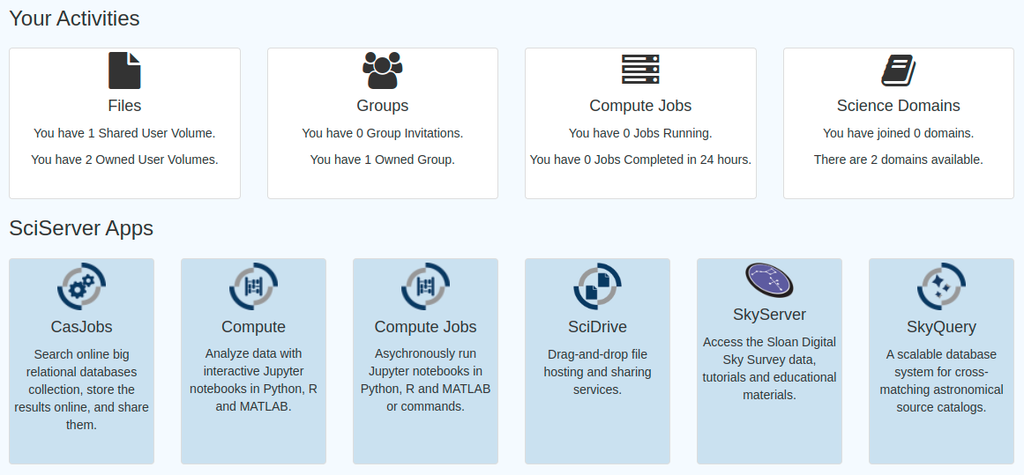

1. You can **choose any arbitrary name** for your container, **check the appropriate boxes** as shown in the image so that your container can access these **User volumes shared by "divyar" user**.

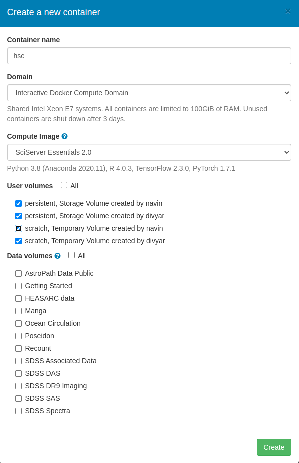

1. Make sure to **read the storage policy carefully** if you want to store your files on SciServer for a long time. It can save you from loosing your valuable data. For the current tutorial, we will **store our codes in "Storage" volume named "persistent"**.

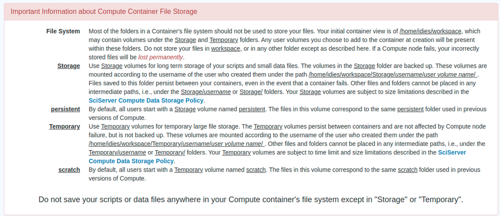

### Your container is ready if it looks something like this -

[figure not shown]

From here, you have to navigate to **Storage/\<your_user_name>/persistent** directory. You can start creating your files in this directory.

Please avoid making a directory in **Storage/ or Storage/\<your_user_name>/** locations, as was explained in the point 5.

### Congratulations!

You are all set up!

From here on, it's just knowing how to use jupyter notebook to write your codes.

## Reading and Plotting the Data

We will first learn how to read files using pandas and then we will plot them to have a feel of the overlap between the lenses and sources.

- pandas, https://pandas.pydata.org/docs/reference/api/pandas.read_csv.html
- numpy, https://numpy.org/doc/stable/
- matplotlib, https://matplotlib.org/

```python
%matplotlib inline
import pandas as pd
import numpy as np
import matplotlib.pyplot as plt
plt.rcParams['figure.figsize'] = [3,3]
plt.rcParams['figure.dpi'] = 250
```

```
Index(['dec', 'lambda', 'ra', 'zred'], dtype='object')
```

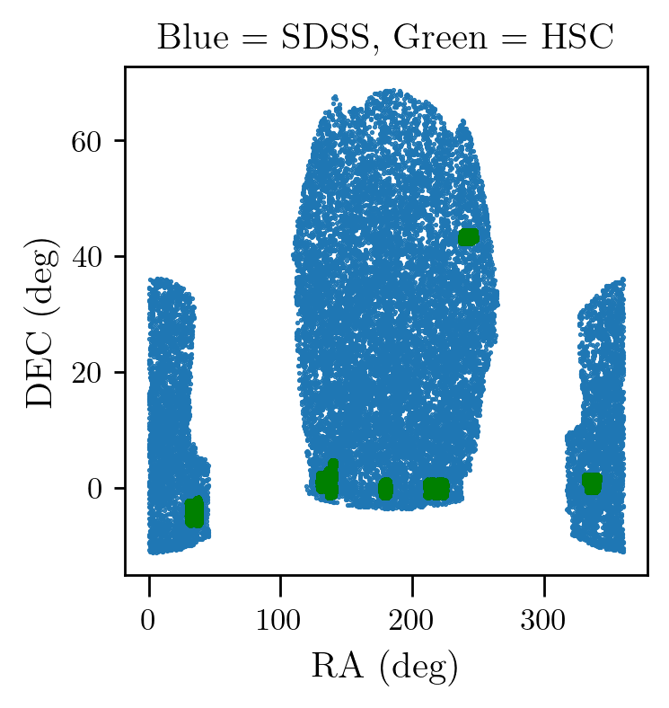

```python
lenses = pd.read_csv('../../weakpipe/DataStore/redmapper.dat', delim_whitespace=1)
print(lenses.keys())
plt.plot(lenses['ra'], lenses['dec'], '.', ms=1.0)

from glob import glob
sflist = glob('../../weakpipe/DataStore/hsc/*.dat')
for fil in sflist:
    src = pd.read_csv(fil, delim_whitespace=1)
    plt.plot(src['ragal'], src['decgal'], 'g.', ms=1.0)
plt.xlabel('RA  (deg)')
plt.ylabel('DEC (deg)')
plt.title('Blue = SDSS, Green = HSC')
```

```
(10, 150)
```

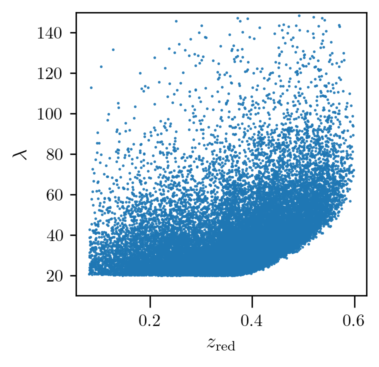

```python
plt.plot(lenses['zred'], lenses['lambda'], '.', ms=1.0)
plt.xlabel(r'$z_{\rm red}$')
plt.ylabel(r'$\lambda$')
plt.ylim(10,150)
```

### In these tutorials we will be working with selection cuts used in arXiv:1707.01907

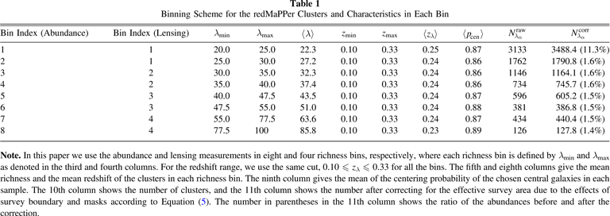

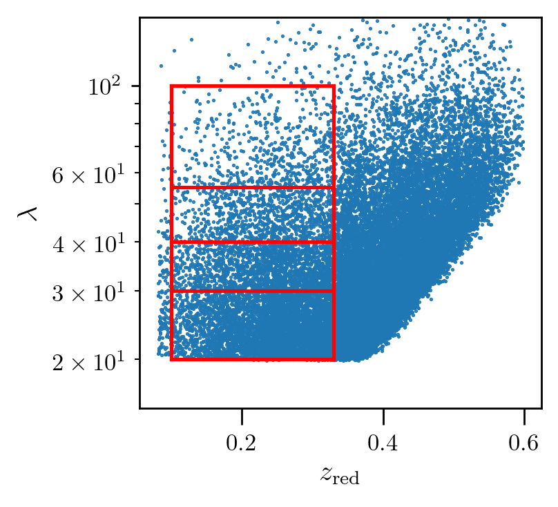

```python
plt.plot(lenses['zred'], lenses['lambda'], '.', ms=1.0)
plt.plot(np.linspace(0.1,0.33,10),20*np.ones(10) , 'r-')
plt.plot(np.linspace(0.1,0.33,10),30*np.ones(10) , 'r-')
plt.plot(np.linspace(0.1,0.33,10),40*np.ones(10) , 'r-')
plt.plot(np.linspace(0.1,0.33,10),55*np.ones(10) , 'r-')
plt.plot(np.linspace(0.1,0.33,10),100*np.ones(10), 'r-')

plt.plot(0.1*np.ones(10), np.linspace(20,100,10) ,  'r-')
plt.plot(0.33*np.ones(10), np.linspace(20,100,10) , 'r-')

plt.xlabel(r'$z_{\rm red}$')
plt.ylabel(r'$\lambda$')
plt.ylim(15,150)
plt.yscale('log')
```

```python
import numpy as np
np.sin
```

```
<ufunc 'sin'>
```